# Case Study 3

```r
#{r, fig.align='center',fig.width=12,fig.height=6, warning=FALSE, message=FALSE}
library(tidyverse)
library(waffle)
library(readr)
gunDeath <- read_csv("https://github.com/fivethirtyeight/guns-data/raw/master/full_data.csv")
gunDeath <- gunDeath[-c(1)]
```

## Gun Deaths

[FiveThirtyEight](https://fivethirtyeight.com/features/gun-deaths/) did a great job explaining gun deaths that happen in the United States. 2/3 of all gun deaths are suicides, about 1/3 are homicides, and the rest are accidents. They collected data such as: gender, race, the type of gun death, and what month it occurred. Here is a similar graphic that they had in their article.

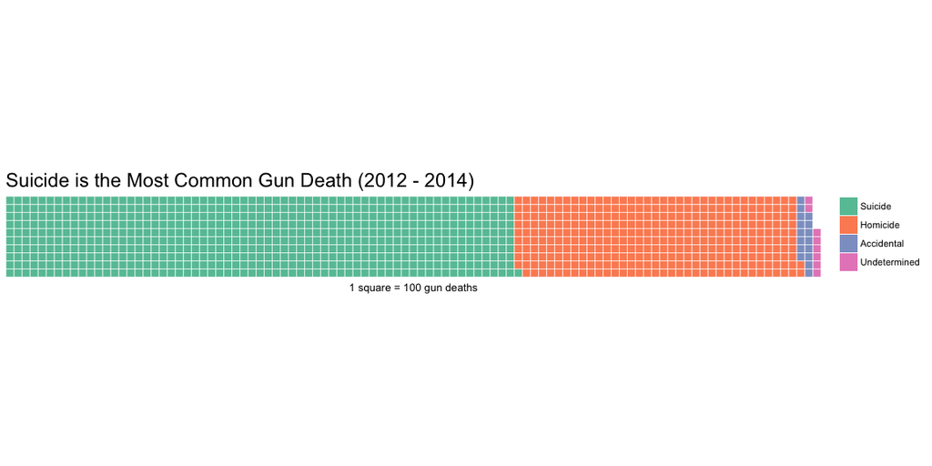

```r
dat <- gunDeath %>%
  filter(intent != is.na(intent)) %>%
  mutate(deathCount = intent) %>%
  group_by(deathCount) %>%
  summarise(count = (n() / 100)) %>%
  arrange(desc(count))
#Need to put names for extra columns for waffle to work.
wafGunDeaths <- setNames(dat$count, dat$deathCount)
waffle(wafGunDeaths, rows = 10,
       title = "Suicide is the Most Common Gun Death (2012 - 2014)",
       xlab = "1 square = 100 gun deaths",
       size = .25)
```

### Race and Gun Death

Suicides definitely have the majority when it comes to gun deaths. We will first take a look at when the most suicides occur and which race is committing suicide the most. The graphic below depicts that most suicides are committed by Whites. They start to increase after February and stays pretty consistent throughout the summer, and then start to go down in the fall.

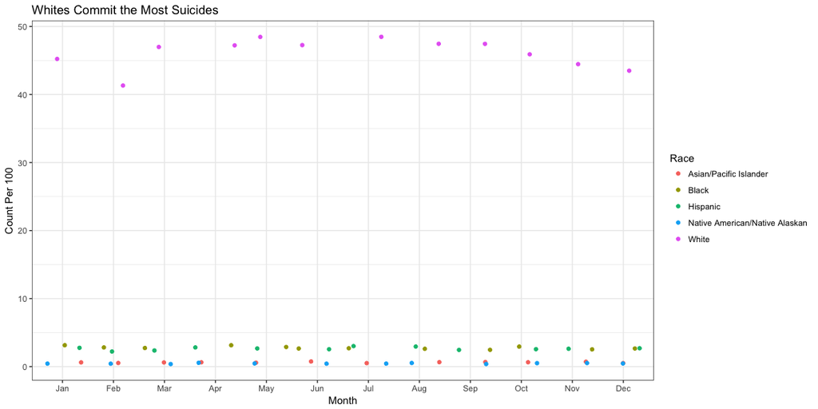

```r
gunDeath %>%
  filter(intent == "Suicide") %>%
  mutate(deathCount = intent) %>%
  group_by(month, race) %>%
  summarise(count = (n() / 100)) %>%
  ggplot(aes(x = month, y = count, color = race)) +
  geom_jitter() +
  scale_x_discrete(
      labels = c("Jan", "Feb", "Mar", "Apr", "May", "Jun", "Jul", "Aug", "Sep", "Oct",
                 "Nov", "Dec")) +
  labs(x = "Month",
      y = "Count Per 100",
      title = "Whites Commit the Most Suicides",
      color = "Race") +
  theme_bw()
```

We will now focus on Homicide deaths looking at the same criteria as the above graphic. It seems that Blacks commit the most Homicides with guns. Again, the deaths start to increase after February, peaks in July, and then starts to go down. Whites are the next closest, but they seem to be pretty consistent throughout the year. The same with Hispanics.

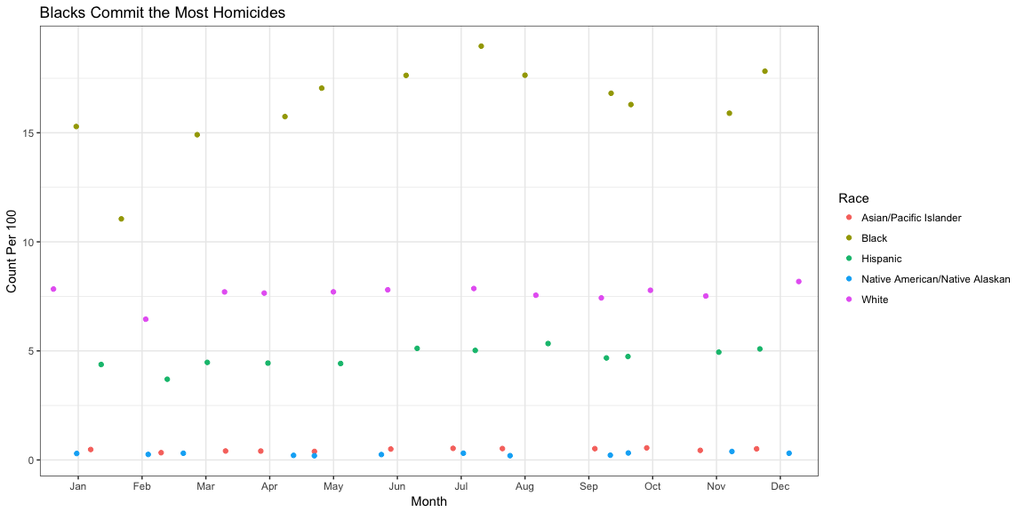

```r
gunDeath %>%
  filter(intent == "Homicide") %>%
  mutate(deathCount = intent) %>%
  group_by(month, race) %>%
  summarise(count = (n() / 100)) %>%
  ggplot(aes(x = month, y = count, color = race)) +
  geom_jitter() +
  scale_x_discrete(
      labels = c("Jan", "Feb", "Mar", "Apr", "May", "Jun", "Jul", "Aug", "Sep", "Oct",
                 "Nov", "Dec")) +
  labs(x = "Month",
      y = "Count Per 100",
      title = "Blacks Commit the Most Homicides",
      color = "Race") +
  theme_bw()
```

My recommendation is to make 2 separate commercials, 1 on suicide and another for homicide. The Suicide commercial should be aired in predominately White communities, and the homicide commercial should be aired in predominately black communities. Start airing the commercials starting in March or April, right before the deaths start piling up. Hopefully, we can start slowing these deaths down so more people can enjoy their summer.